# Report exercice 3

### Elastic Properties Log Processing of Well GT-01 (Delft Geothermal)

#### Exercise 3 - Geomechanics and Structural Geology (March 2026)

- Pablo Oliver - 6483186
- Nanda Najih Habibil Afif - 6424732
- Lennard Stoeck - 6566545

#### *Task:*

Based on the contrast in mechanical properties between different layers, one can predict with what contrast, fracturing in alternating layers occurs in a tensile or compressive regime. This is explained in the manuscript of Boersma et al. (see pdf on Brightspace).

Based on log data of well K12-17 (in which p-wave velocity, s-wave velocity and density is measured, these authors have calculated the mechanical properties (Young’s modulus and Poisson’s ratio) for each layer (Fig. 9 of that pdf). From the contrast between these properties (and the numerical modelling exercise, illustrated in e.g. figures 3 and 7 of that pdf, they have calculated which of those layers is expected to fracture in tension or in compression. Please read this paper and try to reproduce the mechanical stratigraphy (figure 9) for the geothermal well of the Delft Geothermal doublet. The reservoir in the Delft sandstone formation consists of an alternation of shales and sand horizons. Produce a mechanical stratigraphy plot for these layers.

Produce this figure and discuss in 5-6 sentences the importance of your findings.

[output not shown]

```
Depth range: 2507-2934 m
```

```
Clean data points: 4593 (2553-2907 m)
```

|  | DEPT | DTCQI | DTSQI | DENSITY | GR | CN |
| --- | --- | --- | --- | --- | --- | --- |
| count | 4593.000000 | 4593.000000 | 4593.000000 | 4593.000000 | 4593.000000 | 4593.000000 |
| mean | 2731.879497 | 72.052988 | 128.583488 | 2.313434 | 45.583562 | 18.272810 |
| std | 101.117195 | 5.820779 | 9.772790 | 0.766955 | 35.423905 | 5.556752 |
| min | 2552.776200 | 58.901500 | 100.399700 | -7.036000 | 7.796300 | 5.400100 |
| 25% | 2644.444800 | 66.970800 | 122.562800 | 2.310400 | 14.590100 | 15.285200 |
| 50% | 2731.922400 | 73.078000 | 128.624400 | 2.369200 | 30.416500 | 17.726800 |
| 75% | 2819.400000 | 76.701900 | 133.905500 | 2.568400 | 78.296000 | 19.848400 |
| max | 2906.877600 | 88.580600 | 183.323100 | 4.943400 | 138.255200 | 59.329800 |

#### **1. Calculating Velocities from Slowness**

To make the grpahs of the velocitites of P and S waves we have to convert slowness (μs/ft) to velocity (m/s):

#### **2. Calculating Dynamic Elastic Properties**

Based on paper Boersma, Q. D., Douma, L. A. N. R., Bertotti, G., & Barnhoorn, A. (2020). *Mechanical controls on horizontal stresses and fracture behaviour in layered rocks: A numerical sensitivity analysis.* Journal of Structural Geology, 130, 103907. https://doi.org/10.1016/j.jsg.2019.103907, particulary at page 9:

- Bulk Modulus ($K_{dyn}$) $$ K_{dyn} = \rho \left( V_p^2 - \frac{4}{3} V_s^2 \right) \quad [\text{Pa}] $$
- Shear Modulus ($μ_{dyn}$ or $G$) $$ \mu_{dyn} = \rho V_s^2 \quad [\text{Pa}] $$
- Young's Modulus ($E_{dyn}$) $$ E_{dyn} = \frac{9 K_{dyn} \mu_{dyn}}{3 K_{dyn} + \mu_{dyn}} \quad [\text{Pa}] $$
- Poisson's Ratio ($ν_{dyn}$) $$ \nu_{dyn} = \frac{3K_{dyn} - 2\mu_{dyn}}{2(3K_{dyn} + \mu_{dyn})}\quad [\text{Dimensionless}] $$

|  | Vp | Vs | E_dyn_GPa | nu_dyn |
| --- | --- | --- | --- | --- |
| count | 4593.000000 | 4593.000000 | 4593.000000 | 4593.000000 |
| mean | 4.258614 | 2.383993 | 0.000034 | 0.265868 |
| std | 0.352714 | 0.179861 | 0.000013 | 0.043290 |
| min | 3.440934 | 1.662638 | -0.000113 | 0.004009 |
| 25% | 3.973826 | 2.276232 | 0.000031 | 0.235481 |
| 50% | 4.170886 | 2.369690 | 0.000033 | 0.259338 |
| 75% | 4.551237 | 2.486888 | 0.000039 | 0.296708 |
| max | 5.174741 | 3.035866 | 0.000092 | 0.398678 |

#### **3. Plotting in Multi-Panel Elastic Properties Log**

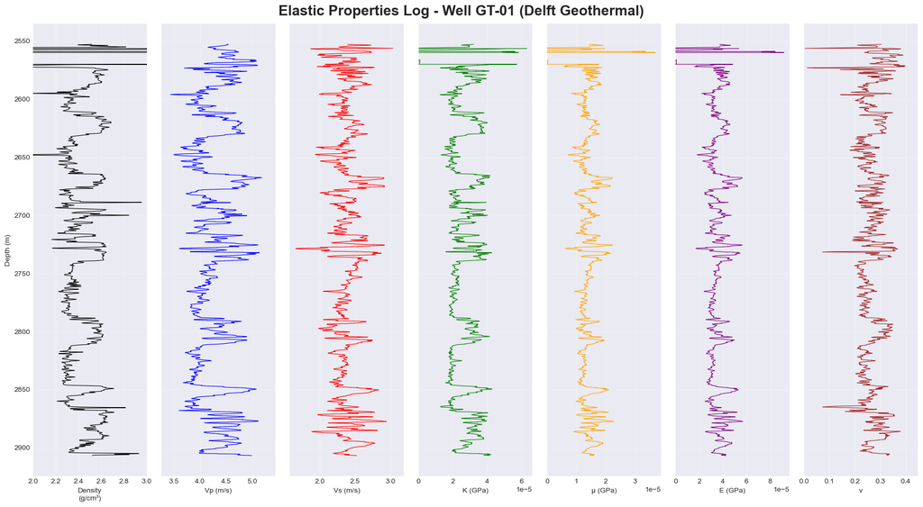

```
Exported 4593 records to CSV
```

#### **4. Mechanical Stratigraphy (Variable Layer Analysis)**

In this step, we generate a mechanical stratigraphy model that identifies stratigraphy layers based on mechanical property contrasts. Some steps and consideration are explained as follow:

1. Calculating rate of change (gradient) in Young's modulus with depth. Changes indicate transition between different lithologies (e.g., shale to sandstone, as dominant lithologies mentioned in the task above).
2. Using the 95th percentile of the gradient distribution as a threshold (this formulation / idea is given by AI). Points exceeding this threshold will be marked as mechanical property changes, then defined as *layer boundaries*.
3. To improve visibility (avoiding too detail layers / too thin), we did merging for layers thinner than 2.5 m with adjacent layers using thickness-weighted averaging. This to ease further geomechanical analysis.
4. Calculating the average Young's modulus (E) and Poisson's ratio (ν) for each boundaries.

```
Total layers (min 2.5m thick): 24
Average thickness: 14.7 m
```

|  | Layer | Depth_min | Depth_max | E_avg | nu_avg | Thickness | Depth_mid |
| --- | --- | --- | --- | --- | --- | --- | --- |
| 0 | 1 | 2552.7762 | 2582.2656 | 0.000017 | 0.294929 | 29.4894 | 2567.5209 |
| 1 | 2 | 2582.3418 | 2588.5140 | 0.000042 | 0.281351 | 6.1722 | 2585.4279 |
| 2 | 3 | 2588.5902 | 2591.7144 | 0.000037 | 0.233859 | 3.1242 | 2590.1523 |
| 3 | 4 | 2591.7906 | 2595.9816 | 0.000030 | 0.252979 | 4.1910 | 2593.8861 |
| 4 | 5 | 2596.0578 | 2605.2780 | 0.000031 | 0.233074 | 9.2202 | 2600.6679 |

#### **Averaged Young's modulus and Poisson's ratio**

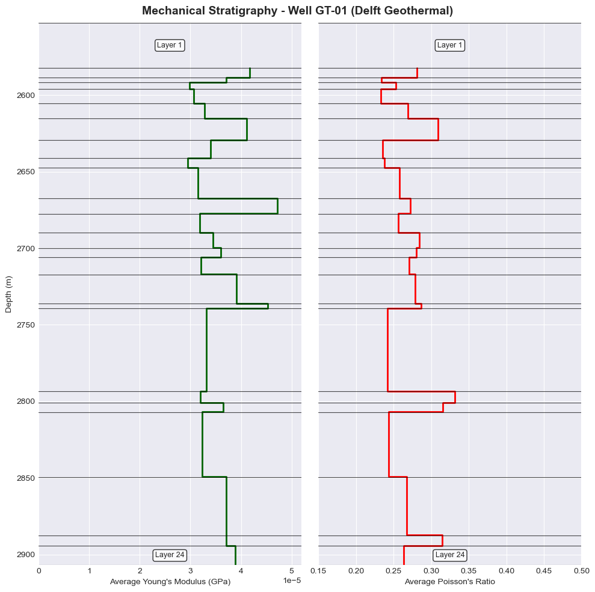

#### **Ratios $E_i$/$E_{i-1}$ and $ν_i$ / $ν_{i-1}$**

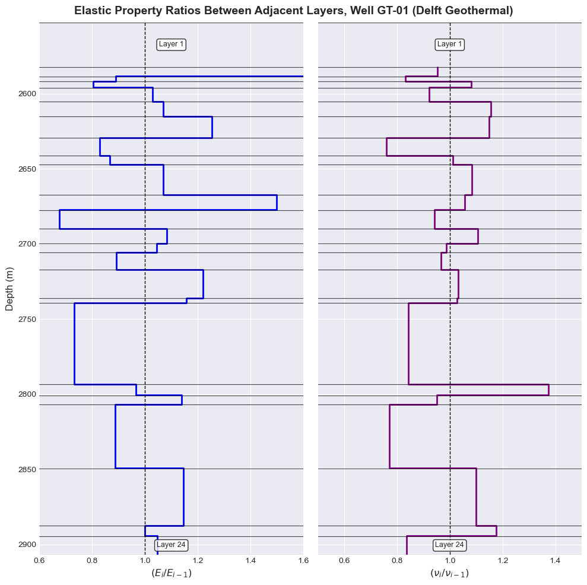

#### **5. Predicted Horizontal Stress and Fracture Behaviour**

Following the methodology from Boersma et al. (2020), we predict the horizontal stress and fracture behaviour for each layer based on the contrast in elastic properties. The prediction is done by placing the average ratios in elastic properties (from the previous analysis) into the stress model.

The normalized horizontal stress parameter is calculated as: $$ \frac{\sigma_h}{\sigma_{applied}} = (E_{ratio} - 1.0) \times (\nu_{avg} - 0.25) \times 2.0 $$

Based on this stress value, layers are classified into different fracture modes:

- **Mode I Tensile**: σ < -0.075 (layers expected to fracture in tension)
- **Hybrid [Tensile]**: -0.075 ≤ σ < 0.0 (transitional with tensile dominance)
- **Hybrid [Shear]**: 0.0 ≤ σ < 0.075 (transitional with shear dominance)
- **Mode II Compressive**: σ ≥ 0.075 (layers expected to fracture in compression)

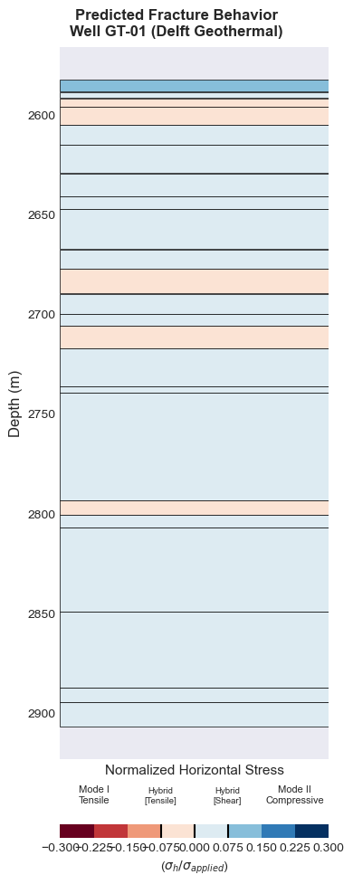

```
Fracture_Mode
Hybrid [Shear]         17
Hybrid [Tensile]        5
Unknown                 1
Mode II Compressive     1
Name: count, dtype: int64

Layers by Fracture Mode:
  Hybrid [Tensile]: 5 layers
  Hybrid [Shear]: 17 layers
  Mode II Compressive: 1 layers
```

#### **Combiened Logs**

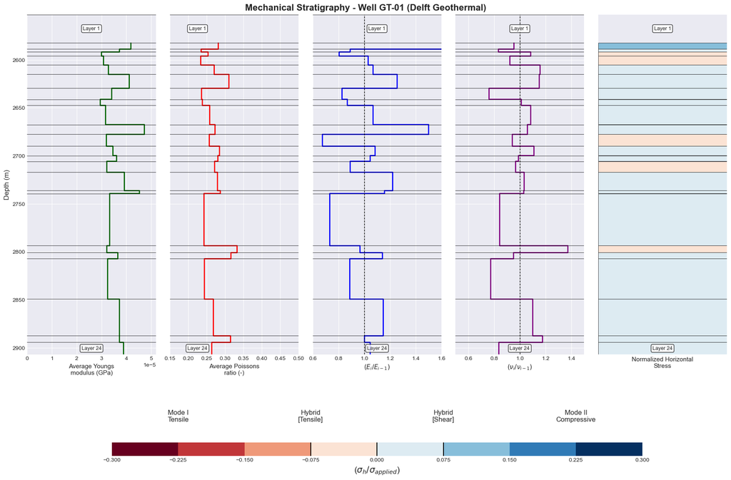

#### **Interpretation**:

The average Young’s modulus provides information about the stiffness of the rock. In Boersma, Q. D., Douma, L. A. N. R., Bertotti, G., & Barnhoorn, A. (2020), we learn that layers with different stiffnesses react very differently from each other. A stiff layer (high $E$) is more likely to experience horizontal tension (Mode I fractures), whereas a layer with a low $E$ will absorb the deformation and undergo horizontal compression. This helps predict the zones where fractures may occur.

The ratio of Poisson’s ratios between two layers controls whether a layer is in tension or compression: "A low ratio in Poisson’s ratio ($\nu_{inner} / \nu_{outer} < 1.0$) results in tensile stresses in the inner layer…". The average Poisson’s ratio is an indicator of how the layer distributes horizontal stress.

The ratio $E_i / E_{i-1}$ measures the contrast in rigidity between two adjacent layers: "the magnitude of these stresses is dependent on the ratio between the elastic parameters of stiffer and softer layers ($E_{stiff} / E_{soft}$)." If $E_i / E_{i-1} >> 1$, the layer tends to be in tension, whereas if $E_i / E_{i-1} << 1$, the layer tends to be in compression. It is a good indicator of where fractures are likely to occur.

The contrast in Poisson’s ratio controls the sign and direction of the principal stress: "a high ratio ($\nu_{inner} / \nu_{outer} > 1.0$) gives compressive stress in the inner layer and tensile stress in the outer layer." If $\nu_i / \nu_{i-1} > 1$, compression is expected, whereas if $\nu_i / \nu_{i-1} < 1$, tension is expected. This ratio explains why some layers are in tension while others directly above are in compression.